# Indicators

#Initial SETUP

```r
#clean
rm(list = ls())
```

```r
# Set the working directory
setwd("C:/Users/srgen/OneDrive/Documentos/Applied Economics/Econometrics/Econometrics II class/Corona EcoII-2/Homework/Paper equipo")
getwd()
```

```
[1] "C:/Users/srgen/OneDrive/Documentos/Applied Economics/Econometrics/Econometrics II class/Corona EcoII-2/Homework/Paper equipo"
```

```r
#Library setup
libs <- c("WDI", "forecast", "ggplot2", "portes", "tseries", "vars", "FactoMineR")
class(libs)
```

```
[1] "character"
```

```r
length(libs)
```

```
[1] 7
```

```r
for (i in libs) {
  if(!is.element(i,.packages(all.available = TRUE))) {
    install.packages(i,repos="https://cran.revolutionanalytics.com/")
  }
  library(i,character.only = TRUE)
}
# path
path <-"C:/Users/srgen/OneDrive/Documentos/Applied Economics/Econometrics/Econometrics II class/Corona EcoII-2/Homework/Paper equipo/"
# some functions
source(paste(path, "functions.r", sep = ""))
```

#Indicators: #LLG LEV: FIRST NAME: “Liquid liabilities to GDP (%)” CODE: “GFDD.DI.05” #PCDM LEV: SECOND NAME: “Private credit by deposit money banks and other financial institutions to GDP (%)” CODE: “GFDD.DI.12” #DCFS LEV: THIRD NAME: “Domestic credit provided by financial sector (% of GDP)” CODE: “FS.AST.DOMS.GD.ZS” #DCPS LEV: FOURTH NAME: “Domestic credit to private sector (% of GDP)” CODE: “FS.AST.PRVT.GD.ZS” #M2 LEV: NO NAME: Masa Monetaria con respecto al PIB CODE: “FM.LBL.BMNY.GD.ZS #GDPMX LEVL:No COL: NAME:”GDP per capita (constant 2010 US$)" CODE: ""NY.GDP.PCAP.KD"" #GDPUS LEVL:No NAME: "GDP per capita (constant 2010 US$)" CODE: "“NY.GDP.PCAP.KD” #GCF NAME:“Gross capital formation (% of GDP)” CODE: “NE.GDI.TOTL.ZS”

library(“WDI”) for World Bank Development Indicators for R https://github.com/vincentarelbundock/WDI How to look for data: WDIsearch(‘gdp.*capita.*constant’)

```r
#import DataFrame
LLG<-WDI(indicator = c("GFDD.DI.05"), country=c('MX'), start=1961, end=2016)
PCDM<-WDI(indicator = c('GFDD.DI.12'), country=c('MX'), start=1961, end=2016)
DCFS<-WDI(indicator = c("FS.AST.DOMS.GD.ZS"), country=c('MX'), start=1961, end=2016)
DCPS<-WDI(indicator = c("FS.AST.PRVT.GD.ZS"), country=c('MX'), start=1961, end=2016)
M2<-WDI(indicator = c("FM.LBL.BMNY.GD.ZS"), country=c('MX'), start=1961, end=2016)
GDPMX<-WDI(indicator = c("NY.GDP.PCAP.KD"), country=c('MX'), start=1961, end=2016)
GDPUS<-WDI(indicator = c("NY.GDP.PCAP.KD"), country=c('US'), start=1961, end=2016)
GCF<-WDI(indicator = c("NE.GDI.TOTL.ZS"), country=c('MX'), start=1961, end=2016)
#reArrange
names(LLG)<-c("code", "C","LLG","yr")
LLG<-LLG[order(LLG$yr),]
names(PCDM)<-c("code", "C","PCDM","yr")
PCDM<-PCDM[order(PCDM$yr),]
names(DCFS)<-c("code", "C","DCFS","yr")
DCFS<-DCFS[order(DCFS$yr),]
names(DCPS)<-c("code", "C","DCPS","yr")
DCPS<-DCPS[order(DCPS$yr),]
names(M2)<-c("code", "C","M2","yr")
M2<-M2[order(M2$yr),]
names(GDPMX)<-c("code", "C","GDPMX","yr")
GDPMX<-GDPMX[order(GDPMX$yr),]
names(GDPUS)<-c("code", "C","GDPUS","yr")
GDPUS<-GDPUS[order(GDPUS$yr),]
names(GCF)<-c("code", "C","GCF","yr")
GCF<-GCF[order(GCF$yr),]
```

# Construcción de Serie de Tiempo

```r
cor(ts)
```

[output not shown]

```
             LLG        PCDM        DCFS        DCPS         M2      GDPMX       GDPUS        GCF
LLG   1.00000000  0.65486907  0.05798596  0.52386535 0.75391745  0.1167789  0.14888924 0.14589336
PCDM  0.65486907  1.00000000 -0.04373656  0.91875910 0.44813217 -0.1749663 -0.01654741 0.05138955
DCFS  0.05798596 -0.04373656  1.00000000  0.11491514 0.53256750  0.1924169  0.01499794 0.13338935
DCPS  0.52386535  0.91875910  0.11491514  1.00000000 0.53408728 -0.2786873 -0.17930445 0.09436918
M2    0.75391745  0.44813217  0.53256750  0.53408728 1.00000000  0.1276892  0.04919849 0.21222087
GDPMX 0.11677894 -0.17496627  0.19241687 -0.27868732 0.12768918  1.0000000  0.94076047 0.58069805
GDPUS 0.14888924 -0.01654741  0.01499794 -0.17930445 0.04919849  0.9407605  1.00000000 0.44678103
GCF   0.14589336  0.05138955  0.13338935  0.09436918 0.21222087  0.5806981  0.44678103 1.00000000
```

# RAiz Unitaria a todas las series.

```r
adf_mat <- matrix(0, ncol(ts), 2)
rownames(adf_mat) <- colnames(ts)
colnames(adf_mat) <- c("levels", "fd")
for(i in 1 : ncol(ts)){
  adf_mat[i,"levels"] <- adf(ts[,i], "none")$p.value
  adf_mat[i,"fd"] <- adf(diff(ts[,i]), "none")$p.value
}
```

```
p-value smaller than printed p-valuep-value smaller than printed p-valuep-value smaller than printed p-valuep-value smaller than printed p-valuep-value smaller than printed p-valuep-value greater than printed p-valuep-value smaller than printed p-value
```

```r
adf_mat
```

```
         levels         fd
LLG   0.6926144 0.01000000
PCDM  0.5868001 0.01135683
DCFS  0.8411314 0.01000000
DCPS  0.5521715 0.01000000
M2    0.7655132 0.01000000
GDPMX 0.9889483 0.01000000
GDPUS 0.9900000 0.05297422
GCF   0.7372678 0.01000000
```

# Serie de Tiempo para índice financiero

```r
tsf<-cbind(LLG$LLG, PCDM$PCDM, DCFS$DCFS, DCPS$DCPS)
tsf<-ts(scale(tsf),names=c("LLG","PCDM", "DCFS", "DCPS"), start= min(PCDM$yr), end=max(PCDM$yr), frequency=1)
head(tsf)
```

```
Time Series:
Start = 1961
End = 1966
Frequency = 1
            LLG      PCDM       DCFS       DCPS
1961 -0.3487348 0.1657102 -1.6933929 0.02311473
1962  0.1007871 0.5396404 -1.4451263 0.36675623
1963  0.3022863 0.6092385 -1.3767114 0.32187344
1964  0.2348626 0.4908935 -1.2473560 0.30373490
1965  0.4743030 0.5973211 -0.9673890 0.26583071
1966  0.3237420 0.6197304 -0.7199127 0.41542209
attr(,"scaled:center")
[1] 23.47803 19.48494 40.33355 22.12625
attr(,"scaled:scale")
[1] 3.239219 6.033212 8.811378 6.759304
```

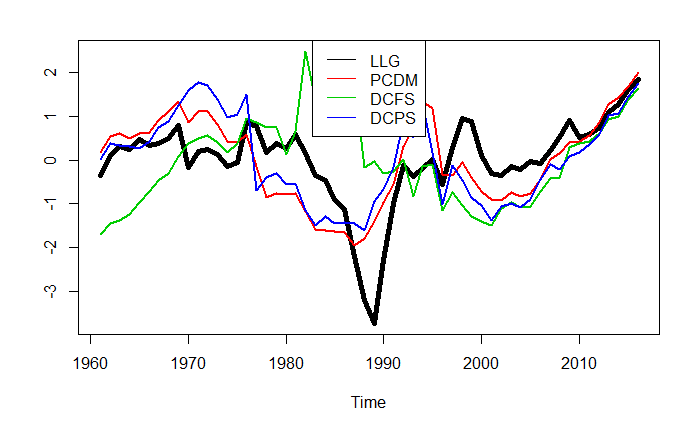

```r
ts.plot((tsf),  col=c(1,2,3,4), lwd=c(5,2,2,2))
legend("top", colnames(tsf), col = c(1:4), lty = 1)
```

# RAiz Unitaria a series financieras.

```r
adf_matf <- matrix(0, ncol(tsf), 2)
rownames(adf_matf) <- colnames(tsf)
colnames(adf_matf) <- c("levels", "fd")
for(i in 1 : ncol(tsf)){
  adf_matf[i,"levels"] <- adf(tsf[,i], "none")$p.value
  adf_matf[i,"fd"] <- adf(diff(tsf[,i]), "none")$p.value
}
```

```
p-value smaller than printed p-valuep-value smaller than printed p-valuep-value smaller than printed p-value
```

```r
adf_matf
```

```
         levels         fd
LLG  0.09562231 0.01000000
PCDM 0.06990223 0.01135683
DCFS 0.14224727 0.01000000
DCPS 0.04150256 0.01000000
```

# Construccion del Indice

```r
pc1<-PCA(tsf, scale.unit=FALSE, ncp=4, graph = FALSE)
head(pc1$eig)
```

```
       eigenvalue percentage of variance cumulative percentage of variance
comp 1 2.37243180              60.389173                          60.38917
comp 2 0.99270113              25.268756                          85.65793
comp 3 0.51272049              13.051067                          98.70900
comp 4 0.05071802               1.291004                         100.00000
```

```r
head(pc1$var$contrib)
```

```
          Dim.1        Dim.2        Dim.3     Dim.4
LLG  25.9134599 6.130945e-05 71.382279654  2.704199
PCDM 38.4474045 1.535164e+00  5.265158697 54.752272
DCFS  0.2498729 9.826065e+01  0.005366025  1.484112
DCPS 35.3892627 2.041257e-01 23.347195625 41.059416
```

# Findex

```r
findex<-(tsf[,1] * (pc1$var$contrib[1,1]/100)) + (tsf[,2]*(pc1$var$contrib[2,1]/100)) +(tsf[,3]*(pc1$var$contrib[3,1]/100))+(tsf[,4]*(pc1$var$contrib[4,1]/100))
head(findex)
```

```
Time Series:
Start = 1961
End = 1966
Frequency = 1
[1] -0.02270918  0.35977648  0.42303781  0.35396959  0.44422107  0.46737896
```

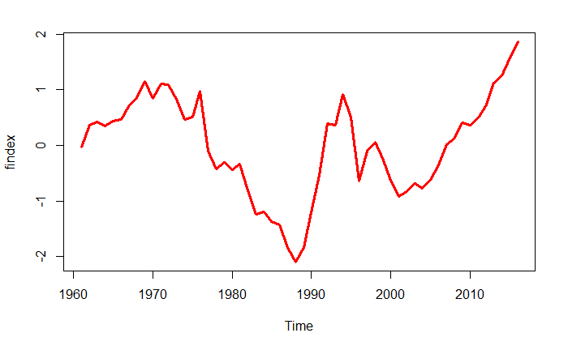

```r
ts.plot(findex, col=2, lwd=3)
```

# Estimacion del Modelo con el Indice financiero

usar findex, GDPMX, GDPUS,

```r
f<-cbind(GDPMX$GDPMX, findex, GDPUS$GDPUS)
head(f)
```

```
Time Series:
Start = 1961
End = 1966
Frequency = 1
     GDPMX$GDPMX      findex GDPUS$GDPUS
1961    3933.911 -0.02270918    17659.06
1962    3990.239  0.35977648    18450.30
1963    4181.010  0.42303781    18986.89
1964    4535.554  0.35396959    19811.02
1965    4709.665  0.44422107    20817.04
1966    4846.037  0.46737896    21915.58
```

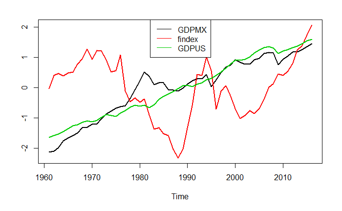

```r
f<-ts(f, names=c("GDPMX", "findex", "GDPUS"), start= min(PCDM$yr), end=max(PCDM$yr), frequency=1)
ts.plot(scale(f), col=c(1,2,3,4), lwd=c(2,2,2,5))
legend("top", colnames(f), col = c(1:4), lty = 1)
```

```r
head(f)
```

```
Time Series:
Start = 1961
End = 1966
Frequency = 1
        GDPMX      findex    GDPUS
1961 3933.911 -0.02270918 17659.06
1962 3990.239  0.35977648 18450.30
1963 4181.010  0.42303781 18986.89
1964 4535.554  0.35396959 19811.02
1965 4709.665  0.44422107 20817.04
1966 4846.037  0.46737896 21915.58
```

```r
#f<-cbind(GDPMX$GDPMX, findex,GDPUS$GDPUS)
#f<-ts(f,start= min(PCDM$yr), end=max(PCDM$yr), frequency=1)
#ts.plot(scale(f), col=c(1,2,3), lwd=c(2,2,2))
```

# Prueba de Raíz unitaria

```r
adf_matm <- matrix(0, ncol(f), 2)
rownames(adf_matm) <- colnames(f)
colnames(adf_matm) <- c("levels", "fd")
for(i in 1 : ncol(f)){
  adf_matm[i,"levels"] <- adf(f[,i], "none")$p.value
  adf_matm[i,"fd"] <- adf(diff(f[,i]), "none")$p.value
}
```

```
p-value smaller than printed p-valuep-value smaller than printed p-valuep-value greater than printed p-value
```

```r
adf_matm
```

```
           levels         fd
GDPMX  0.98894831 0.01000000
findex 0.08324962 0.01000000
GDPUS  0.99000000 0.05297422
```

# Estimar

La estimación sera con US GDP como variable de control

```r
p <- VARselect(f,lag.max=12, type = "const")$selection["HQ(n)"]
p
```

```
HQ(n)
    2
```

```r
# estimamos el VAR
varf <- VAR(f, p = p, type = "const")
summary(varf)
```

```
VAR Estimation Results:
=========================
Endogenous variables: GDPMX, findex, GDPUS
Deterministic variables: const
Sample size: 54
Log Likelihood: -789.478
Roots of the characteristic polynomial:
0.9959 0.8574 0.8574 0.445 0.445 0.05234
Call:
VAR(y = f, p = p, type = "const")


Estimation results for equation GDPMX:
======================================
GDPMX = GDPMX.l1 + findex.l1 + GDPUS.l1 + GDPMX.l2 + findex.l2 + GDPUS.l2 + const

            Estimate Std. Error t value Pr(>|t|)
GDPMX.l1   1.019e+00  1.490e-01   6.836 1.45e-08 ***
findex.l1 -1.217e+02  9.031e+01  -1.347   0.1844
GDPUS.l1   2.756e-02  5.300e-02   0.520   0.6055
GDPMX.l2  -1.665e-01  1.500e-01  -1.110   0.2727
findex.l2  1.228e+02  8.985e+01   1.367   0.1782
GDPUS.l2  -8.908e-03  5.449e-02  -0.163   0.8708
const      5.360e+02  2.013e+02   2.662   0.0106 *
---
Signif. codes:  0 ‘***’ 0.001 ‘**’ 0.01 ‘*’ 0.05 ‘.’ 0.1 ‘ ’ 1


Residual standard error: 232.8 on 47 degrees of freedom
Multiple R-Squared: 0.9798, Adjusted R-squared: 0.9772
F-statistic: 379.4 on 6 and 47 DF,  p-value: < 2.2e-16


Estimation results for equation findex:
=======================================
findex = GDPMX.l1 + findex.l1 + GDPUS.l1 + GDPMX.l2 + findex.l2 + GDPUS.l2 + const

            Estimate Std. Error t value Pr(>|t|)
GDPMX.l1   5.820e-04  1.947e-04   2.989 0.004447 **
findex.l1  9.345e-01  1.180e-01   7.918 3.38e-10 ***
```

[output cut: 32 more lines]

```
F-statistic:  2589 on 6 and 47 DF,  p-value: < 2.2e-16



Covariance matrix of residuals:
           GDPMX   findex     GDPUS
GDPMX  54196.393  8.25284  52000.89
findex     8.253  0.09258     40.21
GDPUS  52000.887 40.20852 368689.70

Correlation matrix of residuals:
        GDPMX findex  GDPUS
GDPMX  1.0000 0.1165 0.3679
findex 0.1165 1.0000 0.2176
GDPUS  0.3679 0.2176 1.0000
```

```r
roots(varf)
```

```
[1] 0.9959175 0.8573821 0.8573821 0.4450218 0.4450218 0.0523380
```

# Estimacion de los residuales.

```r
adf(resid(regref))
```

[output not shown]

```
    Augmented Dickey-Fuller Test

data:  resid(regref)
Dickey-Fuller = -2.3103, Lag order = 3, p-value = 0.02251
alternative hypothesis: stationary
```

# Pruebas de diagnóstico

```r
normality.test(varf)
```

```
$`JB`

    JB-Test (multivariate)

data:  Residuals of VAR object varf
Chi-squared = 25.909, df = 6, p-value = 0.0002315


$Skewness

    Skewness only (multivariate)

data:  Residuals of VAR object varf
Chi-squared = 13.323, df = 3, p-value = 0.003988


$Kurtosis

    Kurtosis only (multivariate)

data:  Residuals of VAR object varf
Chi-squared = 12.586, df = 3, p-value = 0.005623
```

```r
arch.test(varf)
```

```
    ARCH (multivariate)

data:  Residuals of VAR object varf
Chi-squared = 151.82, df = 180, p-value = 0.9376
```

```r
serial.test(varf)
```

```
    Portmanteau Test (asymptotic)

data:  Residuals of VAR object varf
Chi-squared = 113.67, df = 126, p-value = 0.7767
```

# Analisis de Causalidad

Analizar si la causalidad tiene una representación económica en este ejericicio

```r
#causality(varf,cause=c("findex", "GDPUS"))
causalidad <- matrix(0, ncol(f),1)
rownames(causalidad) <-colnames(f)
for (i in 1 : ncol(f)) {
 causalidad[i,] <-causality(varf, cause =colnames(f)[i])$Granger$p.value
}
causalidad
```

```
               [,1]
GDPMX  0.0001232798
findex 0.5736267137
GDPUS  0.0003097454
```

# Funcion impulso respuesa

Las graficas no convergen a 0

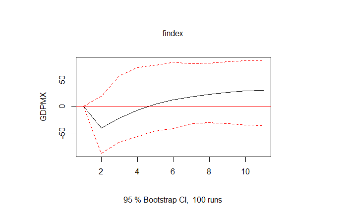

```r
#PLOT de respuesta impulso
opp <- par(mfrow = c(1,1))
for(i in 1 : 2){
  plot(irf(varf, impulse = colnames(f)[i+1], response = "GDPMX"),
    main = colnames(f)[i+1])
}
```

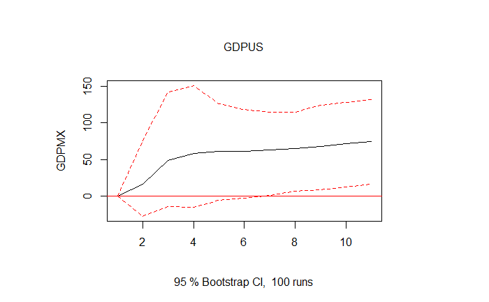

```r
par(opp)
```

# VEC

Como vemos que la raíz unitaria es muy cercano a 1, vamos a implementar el procedimiento de Johansen para encontrar VEC. Las series no cointegran.

```r
johaf <- ca.jo(f, type="eigen", ecdet = "const", K = p)
summary(johaf)
```

```
######################
# Johansen-Procedure #
######################

Test type: maximal eigenvalue statistic (lambda max) , without linear trend and constant in cointegration

Eigenvalues (lambda):
[1] 3.259519e-01 2.292572e-01 1.128407e-01 4.440892e-16

Values of teststatistic and critical values of test:

          test 10pct  5pct  1pct
r <= 2 |  6.47  7.52  9.24 12.97
r <= 1 | 14.06 13.75 15.67 20.20
r = 0  | 21.30 19.77 22.00 26.81

Eigenvectors, normalised to first column:
(These are the cointegration relations)

               GDPMX.l2    findex.l2      GDPUS.l2      constant
GDPMX.l2      1.0000000    1.0000000  1.000000e+00  1.000000e+00
findex.l2   308.7715167  523.1026513 -6.238163e+02  5.769145e+03
GDPUS.l2     -0.1524886   -0.1735797 -9.898073e-02  3.143025e-01
constant  -3279.5679571 -816.4124372 -3.750682e+03 -1.835600e+04

Weights W:
(This is the loading matrix)

              GDPMX.l2     findex.l2      GDPUS.l2      constant
GDPMX.d  -0.0849525178  0.0077865939 -0.0660752977 -1.047597e-16
findex.d -0.0001726847 -0.0001480217  0.0000425653 -2.405628e-19
GDPUS.d  -0.2893266774  0.2711548867  0.0143674101 -6.031394e-17
```